# Homework 1

Şuheda Buse Erduran

12 04 2022

3 different types of monthly economic data, which are Unemployment Levels, Cumhuriyet Gold Prices and Automobile Price Indices are read from EVDS.xlxs from EVDS internet site. Then, the comment part of that Excel file is deleted.The type of the Date column of this file has changed with as.yearmon function and the Unemployment and Gold Prices data sets did not have numeric data, it is also changed.

The other one, which is monthly Google searches for the word ‘Altın’ is read from multiTimeline.xlsx Google Trends internet site. For changing the type of Date column of this file, the same method is implied for this data.

```r
EVDS=read.xlsx("EVDS.xlsx",sheetIndex=1, header=TRUE)
names(EVDS)
```

```
## [1] "Date"           "TP.YISGUCU2.G4" "TP.MK.CUM.YTL"  "TP.FG.J071"
```

```r
EVDS= EVDS[1:97,]
EVDS
```

```
##       Date TP.YISGUCU2.G4 TP.MK.CUM.YTL TP.FG.J071
## 1  2014-01           2849         594.8     151.68
## 2  2014-02           2895        610.75     161.10
## 3  2014-03           2656           631     166.94
## 4  2014-04           2512         598.5     167.83
## 5  2014-05           2426         581.8     166.66
## 6  2014-06           2682        587.75     164.96
## 7  2014-07           2805           594     164.87
## 8  2014-08           2918         599.6     164.79
## 9  2014-09           2979        587.25     164.83
## 10 2014-10           3141         587.6     164.74
## 11 2014-11           2998           574     163.84
## 12 2014-12           3110        589.75     162.89
## 13 2015-01           3375           622     166.79
## 14 2015-02           3362        644.25     170.74
```

[output cut: 83 more lines]

```r
EVDS$Date <- as.yearmon(x = EVDS$Date)
EVDS$TP.YISGUCU2.G4 <- as.numeric(EVDS$TP.YISGUCU2.G4)
EVDS$TP.MK.CUM.YTL <- as.numeric(EVDS$TP.MK.CUM.YTL)

multiTimeline <- read.xlsx("multiTimeline.xlsx", sheetIndex=1, header=TRUE)
multiTimeline$Date <- as.yearmon(x = multiTimeline$Date)
multiTimeline
```

```
##        Date Altın
## 1  Oca 2014    12
## 2  Şub 2014    10
## 3  Mar 2014     9
## 4  Nis 2014     8
## 5  May 2014     7
## 6  Haz 2014     8
## 7  Tem 2014     7
## 8  Ağu 2014     7
## 9  Eyl 2014     7
## 10 Eki 2014     6
## 11 Kas 2014     9
## 12 Ara 2014     9
## 13 Oca 2015    10
## 14 Şub 2015    10
```

[output cut: 83 more lines]

First, for a rough and simple observation, all the data are pairly plotted and their relationship can be seen basically this way.

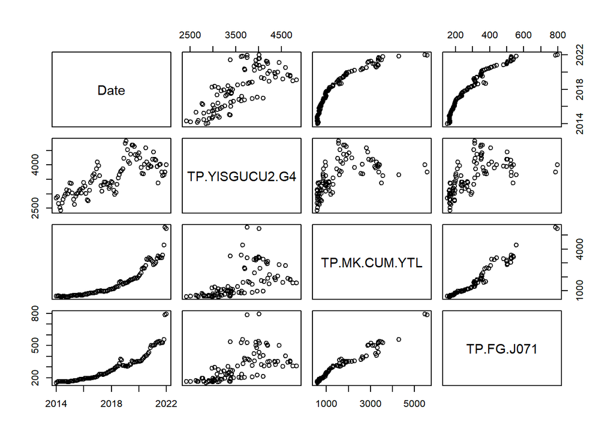

```r
plot(EVDS)
```

With this plot, one can see that there can be a relation between Cumhuriyet Gold Prices and Automobile Price Index because the graphs used these data sets are linear and looks like x=y line. Also, they are increased with respect to the time.

Unemployment Level, Cumhuriyet Gold Prices and Price İndices for Automobiles are plotted by using ggplot() and geom_line() functions. Another graph that is for Google Trends data is also plotted.

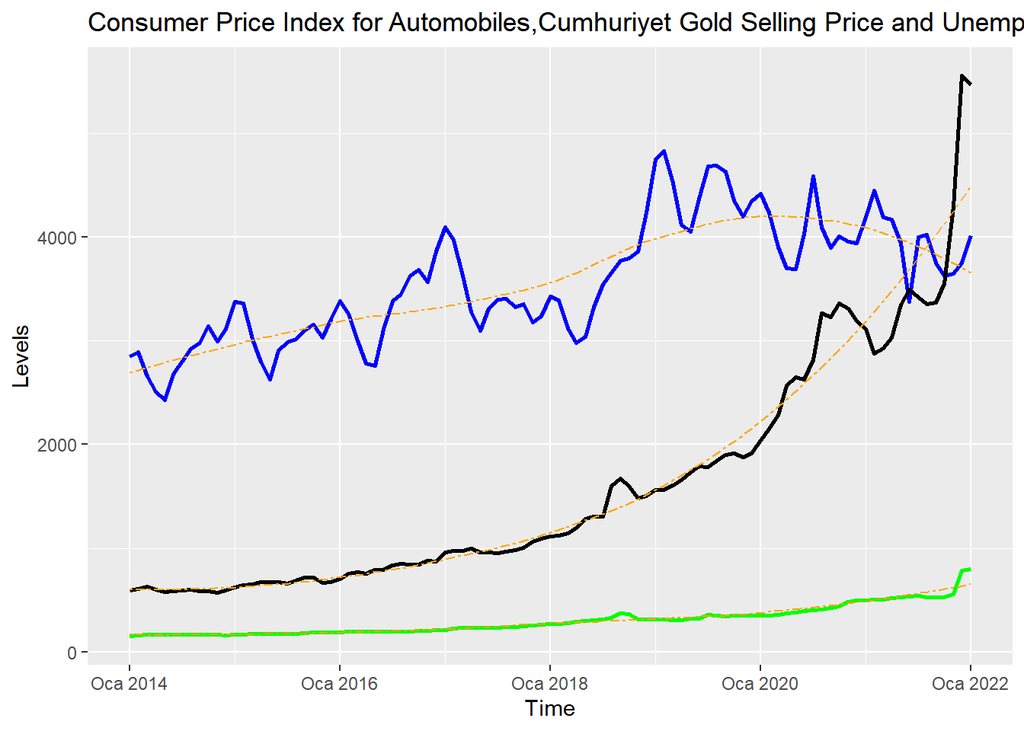

```r
ggplot(data=EVDS)+
  labs(title = "Consumer Price Index for Automobiles,   Cumhuriyet Gold Selling Price and Unemployment Level", x = "Time", y = "Levels" ) +
  geom_line(group=1,size=1,color='blue', aes(x=Date,y=TP.YISGUCU2.G4))+
  geom_smooth(fill = NA, color="orange",linetype = "twodash", size = 0.5, aes(x=Date,y=TP.YISGUCU2.G4)) +
  geom_line(group=1,size=1,aes(x=Date,y=TP.MK.CUM.YTL))+
  geom_smooth(fill = NA, color="orange",linetype = "twodash", size = 0.5, aes(x=Date,y=TP.MK.CUM.YTL)) +
  geom_line(group=1,size=1,color='green', aes(x=Date,y=TP.FG.J071)) +
   geom_smooth(fill = NA, color="orange",linetype = "twodash", size = 0.5, aes(x=Date,y=TP.FG.J071))
```

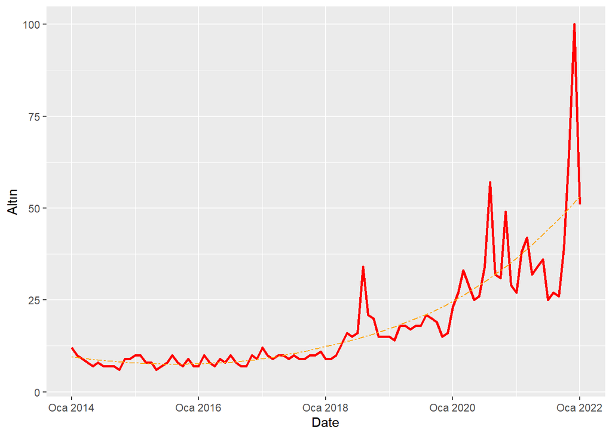

```r
ggplot(data = multiTimeline)+
  geom_line(group =1,size = 1, color ='red', aes(x=Date, y= Altın))+
  geom_smooth(fill = NA, color="orange",linetype = "twodash", size = 0.5, aes(x=Date,y=Altın))
```

Yearly histograms for all the data sets are plotted using ggplot() and geom_histogram() functions. To be able to make these graphs yearly, the Date column is used and a new column, which is Year column is added.

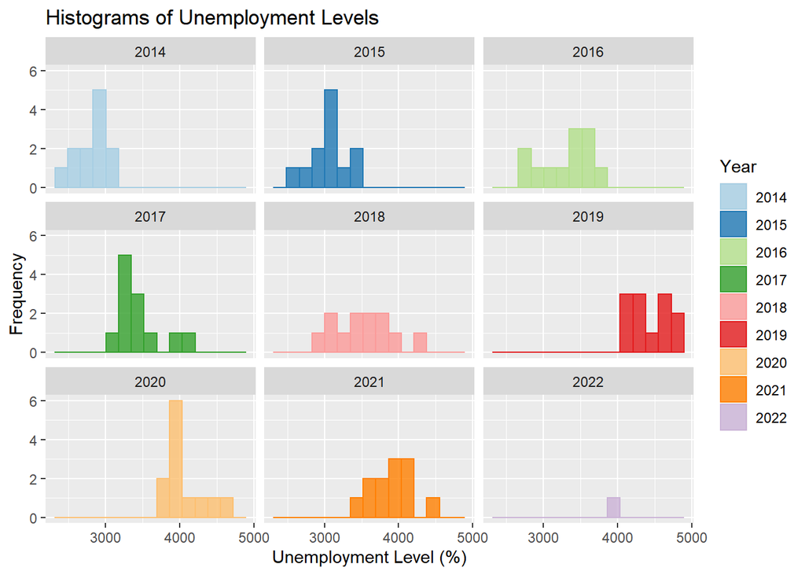

```r
EVDS$Year <- factor(format(x = EVDS$Date, format = "%Y"), ordered = TRUE)

ggplot(data = EVDS,aes(x = TP.YISGUCU2.G4)) +
  geom_histogram(bins=15,alpha=0.8,aes(color=Year,fill=Year))+
  facet_wrap(facets= .~Year)+
  scale_color_brewer(palette = "Paired",aesthetics = c("color", "fill")) +
  labs(title = "Histograms of Unemployment Levels",
       x = "Unemployment Level (%)",
       y = "Frequency")
```

Unemployment Levels have increased until 2019. After that period, it has slightly decreased.

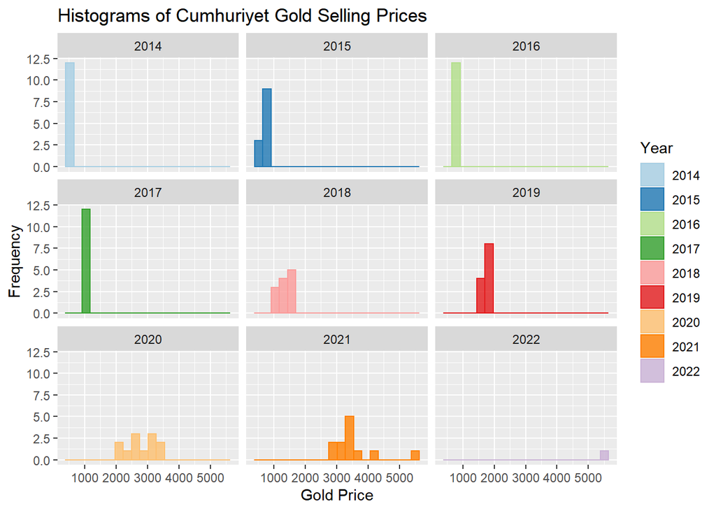

```r
ggplot(data = EVDS,aes(x = TP.MK.CUM.YTL)) +
  geom_histogram(bins=20,alpha=0.8,aes(color=Year,fill=Year))+
  facet_wrap(facets= .~Year)+
  scale_color_brewer(palette = "Paired",aesthetics = c("color", "fill")) +
  labs(title = "Histograms of Cumhuriyet Gold Selling Prices",
       x = "Gold Price",
       y = "Frequency")
```

From 2014 to 2019, there can be seen a slight increase. However, by time passes, this increasing trend has accelerated. The reason why there are more bars in 2020 and 2021, the Gold Prices vary in less fraction of time.

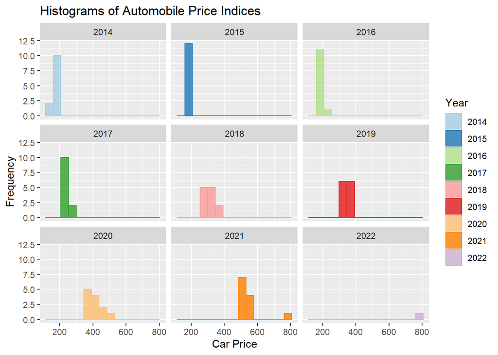

```r
ggplot(data = EVDS,aes(x = TP.FG.J071)) +
  geom_histogram(bins=15,alpha=0.8,aes(color=Year,fill=Year))+
  facet_wrap(facets= .~Year)+
  scale_color_brewer(palette = "Paired",aesthetics = c("color", "fill")) +
  labs(title = "Histograms of Automobile Price Indices",
       x = "Car Price",
       y = "Frequency")
```

```r
multiTimeline$Year <- factor(format(x = multiTimeline$Date, format = "%Y"), ordered = TRUE)
```

Similar to the Gold Prices, Automobile Price Indices has increased year by year. At 2020, the Prices have varied more.

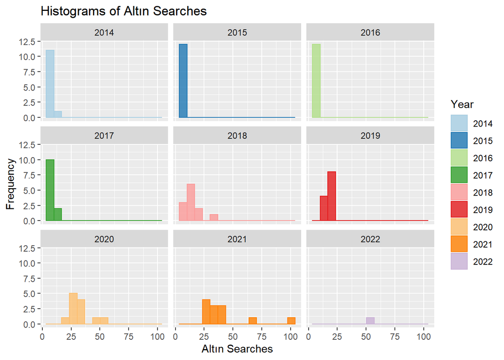

```r
ggplot(data = multiTimeline,aes(x = Altın)) +
  geom_histogram(bins=15,alpha=0.8,aes(color=Year,fill=Year))+
  facet_wrap(facets= .~Year)+
  scale_color_brewer(palette = "Paired",aesthetics = c("color", "fill")) +
  labs(title = "Histograms of Altın Searches",
       x = "Altın Searches",
       y = "Frequency")
```

It can be seen at the above histogram that, as the Gold Prices İncrease, people are more concerned about and interested in Gold prices. The correlation between them is logical and it is observed in accordance with what is expected.

Yearly box-plots are plotted:

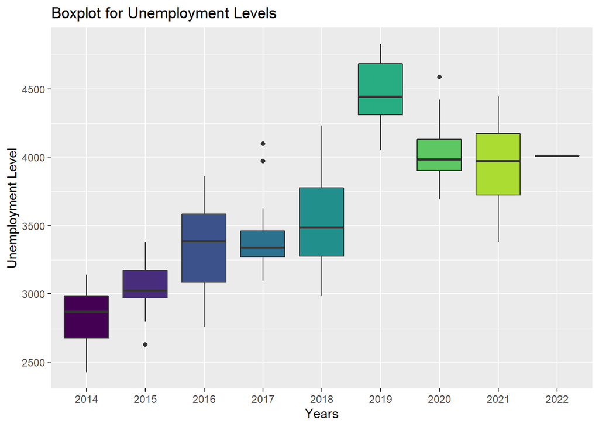

```r
ggplot(EVDS,aes(x=factor(Year),y=TP.YISGUCU2.G4))+
  geom_boxplot(aes(fill=factor(Year)))+
  xlab("Years") + ylab("Unemployment Level")+
  ggtitle("Boxplot for Unemployment Levels")+
  theme(legend.position = "none")
```

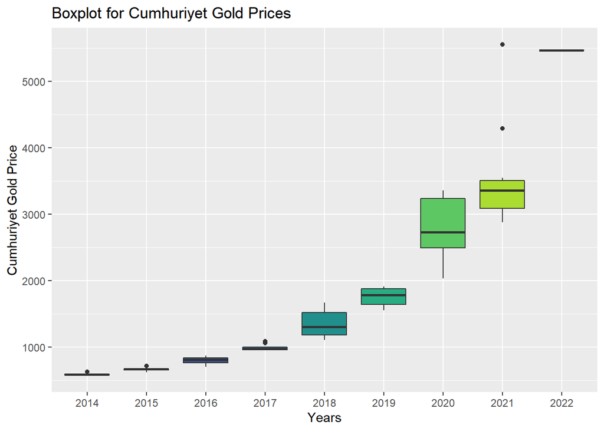

```r
ggplot(EVDS,aes(x=factor(Year),y=TP.MK.CUM.YTL))+
  geom_boxplot(aes(fill=factor(Year)))+
  xlab("Years") + ylab("Cumhuriyet Gold Price")+
  ggtitle("Boxplot for Cumhuriyet Gold Prices")+
  theme(legend.position = "none")
```

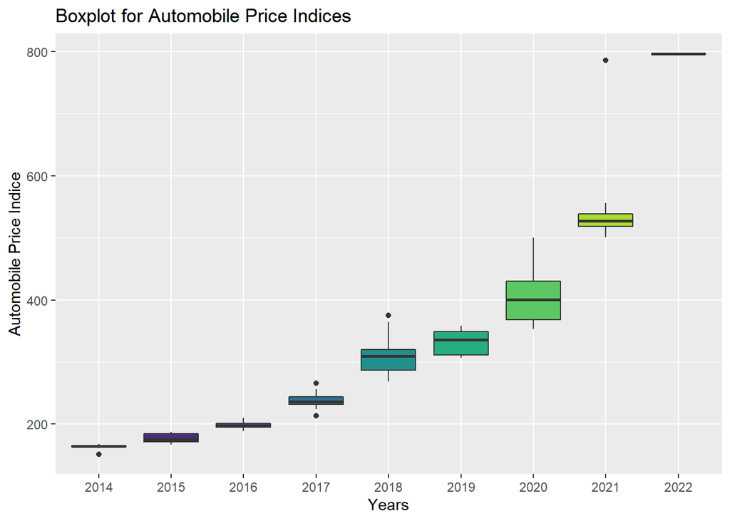

```r
ggplot(EVDS,aes(x=factor(Year),y=TP.FG.J071))+
  geom_boxplot(aes(fill=factor(Year)))+
  xlab("Years") + ylab("Automobile Price Indice")+
  ggtitle("Boxplot for Automobile Price Indices")+
  theme(legend.position = "none")
```

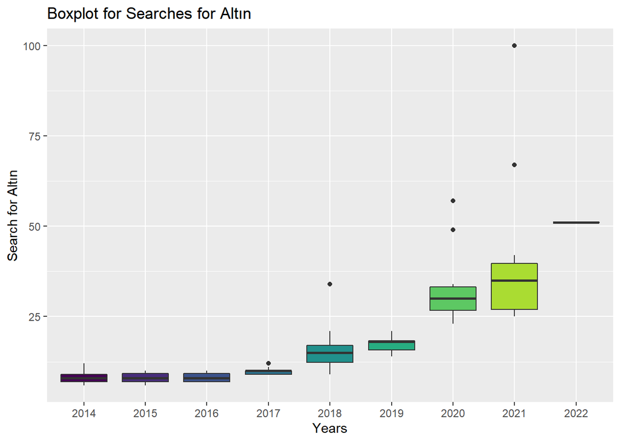

```r
ggplot(multiTimeline,aes(x=factor(Year),y=Altın))+
  geom_boxplot(aes(fill=factor(Year)))+
  xlab("Years") + ylab("Search for Altın")+
  ggtitle("Boxplot for Searches for Altın")+
  theme(legend.position = "none")
```

At the box plot of Unemployment, it is observed that, these levels are fluctuated, both yearly and monthly. The expected variances after seeing the histograms can be more clearly seen at box plots at Cumhuriyet Gold Prices, Automobile Price Indices and Altın Searches. For example, at the year 2020, the boxes are wider than before for all those three box plots.

**Conclusion:** The aim of this homework was choosing 3 data sets from EVDs and one word which is searched at Google and looking at their relationships if they exist between any of these variables. For this purpose, Unemployment Levels, Cumhuriyet Gold Prices and Price Indices for Automobile are chosen from EVDS and the word ‘Altın’ is chosen from Google Trends. The period between January 2014 and January 2022 is chosen because there were the years which includes all of those data sets. Pairs Plot, Line Graphs, Histograms and Box plots are plotted in order to see if there exist any relation between all 4 data sets. It can be seen at all the plots for Cumhuriyet Gold Prices, Automobile Price Indices and Altın Searches, that all those variables generally increase as the time passes.For the Unemployment Level data, one can say that it fluctuates more but it also increases more than decrease. There is one more thing which might be observes here is, the changes of Cumhuriyet Gold Prices, Automobile Price Indices and Altın Searches might be related to each other, or all the three data sets might be related to the same thing such as time, economic conditions etc.